# Running quality control of droplet-level single-cell data with singleCellTK

# Introduction

Performing comprehensive quality control (QC) is necessary to remove poor quality cells for downstream analysis of single-cell RNA sequencing (scRNA-seq) data. Within droplet-based scRNA-seq data, droplets containing cells must be differentiated from empty droplets. Therefore, assessment of the data is required, for which various QC algorithms have been developed. In singleCellTK, we have written convenience functions for several of these tools. In this guide, we will demonstrate how to use these functions to perform quality control on unfiltered, droplet-level data.

The package can be loaded using the `library` command.

```r
library(singleCellTK)
```

# Quality Control of Droplet Counts Data

## Load PBMC4k data from 10X

singleCellTK takes in a `SingleCellExperiment` object from the [SingleCellExperiment](https://bioconductor.org/packages/release/bioc/html/SingleCellExperiment.html) package. In this user guide, we will install the 10X PBMC 4K dataset from the 10X Genomics website using the `BiocFileCache`(https://www.bioconductor.org/packages/release/bioc/html/BiocFileCache.html) package as an example dataset for the quality control of droplet-based counts data.

```r
# Install BiocFileCache if is it not already
if (!requireNamespace("BiocFileCache", quietly = TRUE)) {
  if (!requireNamespace("BiocManager", quietly = TRUE)) {
    install.packages("BiocManager")
  }
  BiocManager::install("BiocFileCache")
}

library("BiocFileCache")
bfc <- BiocFileCache::BiocFileCache("raw_data", ask = FALSE)
raw.path <- bfcrpath(bfc, file.path(
  "http://cf.10xgenomics.com/samples",
  "cell-exp/2.1.0/pbmc4k/pbmc4k_raw_gene_bc_matrices.tar.gz"
))
untar(raw.path, exdir = file.path(tempdir(), "pbmc4k"))

fname <- file.path(tempdir(), "pbmc4k/raw_gene_bc_matrices/GRCh38")
pbmc4k <- DropletUtils::read10xCounts(fname, col.names = TRUE)
```

## runDropletQC

All droplet-based QC functions are able to be run under the wrapper function `runDropletQC`. By default all possible QC algorithms will be run.

```r
pbmc4k <- runDropletQC(pbmc4k)
```

If users choose to only run a specific set of algorithms, they can specify which to run with the `algorithms` parameter.

When quality control functions are run in singleCellTK, the output of the function is stored in the `colData` slot of the `SingleCellExperiment` object.

```r
head(colData(pbmc4k), 5)
```

|  | Sample | Barcode | sum | detected | percent_top_50 | percent_top_100 | percent_top_200 | percent_top_500 | total | dropletUtils_emptyDrops_total | dropletUtils_emptyDrops_logprob | dropletUtils_emptyDrops_pvalue | dropletUtils_emptyDrops_limited | dropletUtils_emptyDrops_fdr | dropletUtils_BarcodeRank_Knee | dropletUtils_BarcodeRank_Inflection |
| --- | --- | --- | --- | --- | --- | --- | --- | --- | --- | --- | --- | --- | --- | --- | --- | --- |
| AAACCTGAGAAACCAT-1 | /scratch/8811246.1.cbm.q/Rtmpj1cQ34/pbmc4k/raw_gene_bc_matrices/GRCh38 | AAACCTGAGAAACCAT-1 | 1 | 1 | 100 | 100 | 100 | 100 | 1 | 1 | NA | NA | NA | NA | 0 | 0 |
| AAACCTGAGAAACCGC-1 | /scratch/8811246.1.cbm.q/Rtmpj1cQ34/pbmc4k/raw_gene_bc_matrices/GRCh38 | AAACCTGAGAAACCGC-1 | 0 | 0 | NaN | NaN | NaN | NaN | 0 | 0 | NA | NA | NA | NA | 0 | 0 |
| AAACCTGAGAAACCTA-1 | /scratch/8811246.1.cbm.q/Rtmpj1cQ34/pbmc4k/raw_gene_bc_matrices/GRCh38 | AAACCTGAGAAACCTA-1 | 1 | 1 | 100 | 100 | 100 | 100 | 1 | 1 | NA | NA | NA | NA | 0 | 0 |
| AAACCTGAGAAACGAG-1 | /scratch/8811246.1.cbm.q/Rtmpj1cQ34/pbmc4k/raw_gene_bc_matrices/GRCh38 | AAACCTGAGAAACGAG-1 | 0 | 0 | NaN | NaN | NaN | NaN | 0 | 0 | NA | NA | NA | NA | 0 | 0 |
| AAACCTGAGAAACGCC-1 | /scratch/8811246.1.cbm.q/Rtmpj1cQ34/pbmc4k/raw_gene_bc_matrices/GRCh38 | AAACCTGAGAAACGCC-1 | 1 | 1 | 100 | 100 | 100 | 100 | 1 | 1 | NA | NA | NA | NA | 0 | 0 |

A summary of all outputs is shown below:

| QC output | Description | Methods | Package/Tool |
| --- | --- | --- | --- |
| dropletUtils_emptyDrops_total | Total counts | runEmptyDrops | DropletUtils |
| dropletUtils_emptyDrops_logprob | The log-probability of droplet being empty | runEmptyDrops | DropletUtils |
| dropletUtils_emptyDrops_pvalue | Monte Carlo p-value of droplet being empty | runEmptyDrops | DropletUtils |
| dropletUtils_emptyDrops_limited | Whether a lower p-value could be obtained by increasing niters | runEmptyDrops | DropletUtils |
| dropletUtils_emptyDrops_fdr | p-value of droplet being empty, corrected for false detection rate | runEmptyDrops | DropletUtils |
| dropletUtils_BarcodeRank_Knee | Whether total UMI count value is higher than knee point | runBarcodeRankDrops | DropletUtils |
| dropletUtils_BarcodeRank_Inflection | Whether total UMI count value is higher than inflection point | runBarcodeRankDrops | DropletUtils |

## Plotting QC metrics

Upon running runDropletQC, the QC outputs will need to be plotted. For each QC method, singleCellTK contains specialized plotting functions that may be used for the generation of QC plots.

### EmptyDrops

It is crucial to distinguish the data occurring from real cells and empty droplets containing ambient RNA. SCTK employs the [EmptyDrops](https://rdrr.io/github/MarioniLab/DropletUtils/man/emptyDrops.html) algorithm from the [DropletUtils](https://bioconductor.org/packages/release/bioc/html/DropletUtils.html) package to test for empty droplets.

The wrapper function `plotEmptyDropsResults` can be used to plot the results from the EmptyDrops algorithm. This will visualize the empty droplets, by plotting the total UMI counts against the log probability for each barcode.

```r
emptyDropsResults <- plotEmptyDropsResults(
  inSCE = pbmc4k,
  axisLabelSize = 20,
  sample = NULL,
  fdrCutoff = 0.01,
  dotSize = 0.5,
  defaultTheme = TRUE
)
```

```r
emptyDropsResults$scatterEmptyDrops
```

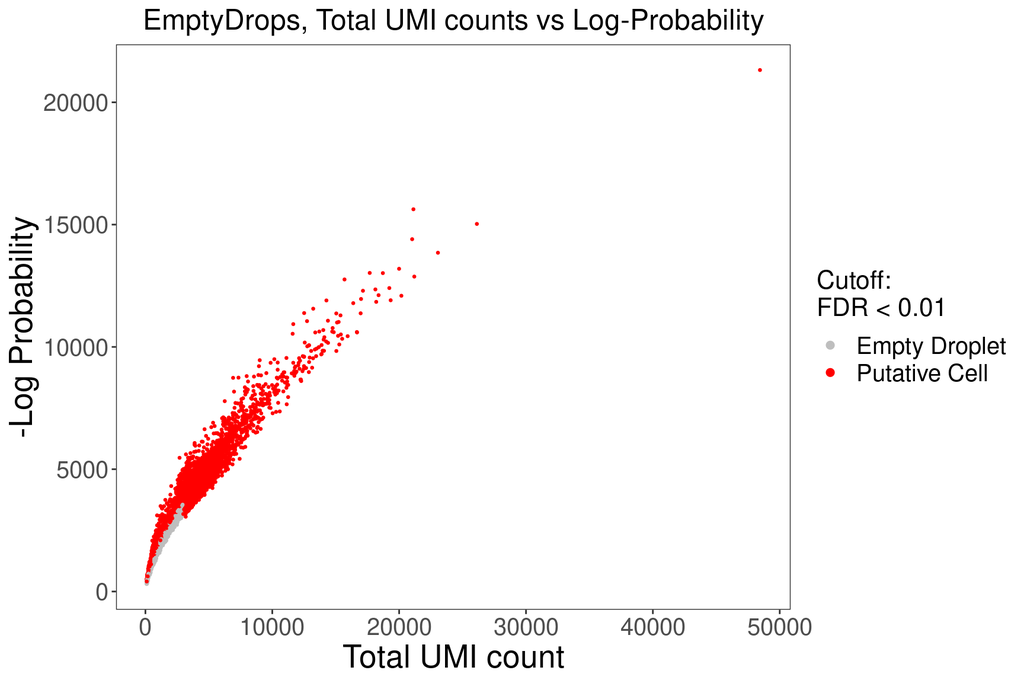

Data points are colored by FDR values, where we see a small portion of the dataset contains barcodes that do not meet the threshold.

### BarcodeRanks

[BarcodeRanks](https://rdrr.io/bioc/DropletUtils/man/barcodeRanks.html) from the [DropletUtils](https://bioconductor.org/packages/release/bioc/html/DropletUtils.html) package computes barcode rank statistics and identifies the knee and inflection points on the total count curve. The knee and inflection points on the curve represent the difference between empty droplets and cell-containing droplets with much more RNA. The wrapper function `plotBarcodeRankDropsResults` can be used to plot the results from the BarcodeRanks algorithm.

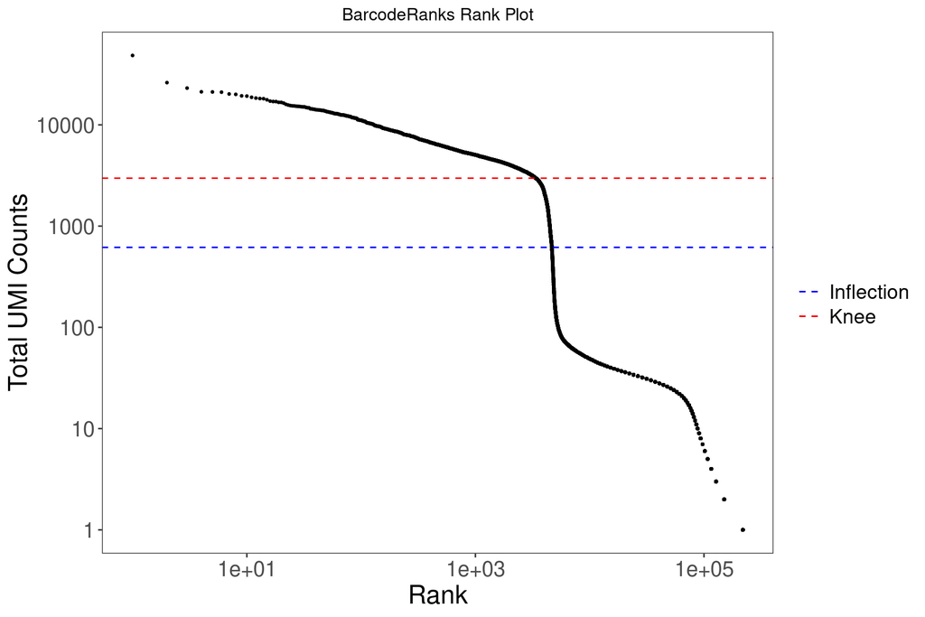

```r
plotBarcodeRankDropsResults(
  inSCE = pbmc4k,
  title = "BarcodeRanks Rank Plot",
  legendSize = 14
)
```

The total UMI count of each barcode is plotted against its rank, where we see a steep dropoff of UMI counts around the inflection point, where we see a separation between cell containing and empty droplets.

## Filtering the dataset

SingleCellExperiment objects can be subset by its colData using `subsetSCECols`. The `colData` parameter takes in an expression in character vector form which will be used to identify a subset of columns using variables found in the colData of the SingleCellExperiment object. For example, if x is a numeric vector in colData, then “x < 5” will return all columns with x less than 5. The `index` parameter takes in a vector of indices which should be kept, while `bool` takes in a vector of TRUE or FALSE which should be the same length as the number of columns in the SingleCellExperiment object.

```r
#Before filtering:
dim(pbmc4k)
```

```
## [1]  33694 737280
```

```r
pbmc4k <- subsetSCECols(pbmc4k, colData = 'dropletUtils_BarcodeRank_Inflection == 1')
pbmc4k <- subsetSCECols(pbmc4k, colData = '!is.na(pbmc4k$dropletUtils_emptyDrops_fdr)')
pbmc4k <- subsetSCECols(pbmc4k, colData = 'pbmc4k$dropletUtils_emptyDrops_fdr < 0.01')
```

```r
#After filtering:
dim(pbmc4k)
```

```
## [1] 33694  4178
```

We can compare the average total UMI counts per cell before and after cell filtration:

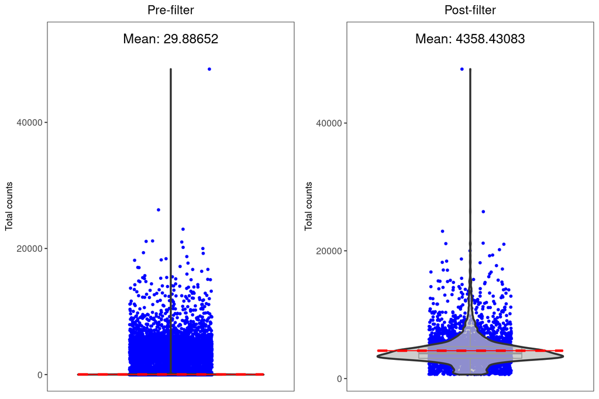

For additional cell-filtered quality control with singleCellTK, please refer to “Running quality control of cell-filtered single cell data with singleCellTK”.

## Running individual QC methods

Instead of running all quality control methods on the dataset at once, users may elect to execute QC methods individually. The parameters as well as the outputs to individual QC functions are described in detail as follows:

### runEmptyDrops

The wrapper function `runEmptyDrops` can be used to separately run the EmptyDrops algorithm on its own.

In `runEmptyDrops`, the `lower` parameter is the lower bound of the total UMI count, in which all barcodes below the lower bound are assumed to be empty droplets. The `niters` parameter is the number of iterations the function will run for the calculation. `testAmbient` indicates whether results should be returned for barcodes that have a total UMI count below what is specified in `lower`.

```r
pbmc4k <- runEmptyDrops(
  inSCE = pbmc4k,
  useAssay = "counts",
  lower = 100,
  niters = 10000
)
```

### runBarcodeRankDrops

The wrapper function `runBarcodeRankDrops` can be used to separately run the BarcodeRanks algorithm on its own.

The `lower` parameter is again the lower bound of the total UMI count, in which all barcodes below the lower bound are assumed to be empty droplets.

```r
pbmc4k <- runBarcodeRankDrops(
  inSCE = pbmc4k,
  useAssay = "counts",
  fitBounds = NULL, df = 20
)
```